# Homework 3

Regan Honeycutt

1/27/2022

## Univariate Assignment

Read in tree data

```r
# read in directly from website:
trees <- read.csv('https://raw.githubusercontent.com/dmcglinn/quant_methods/gh-pages/data/treedata_subset.csv')
# or download and import locally
trees <- read.csv('./data/treedata_subset.csv')
```

```r
trees <- read.csv('https://raw.githubusercontent.com/dmcglinn/quant_methods/gh-pages/data/treedata_subset.csv')
str(trees)
```

```
## 'data.frame':    8038 obs. of  9 variables:
##  $ plotID    : chr  "ATBN-01-0403" "ATBN-01-0532" "ATBN-01-0533" "ATBN-01-0536" ...
##  $ spcode    : chr  "ABIEFRA" "ABIEFRA" "ABIEFRA" "ABIEFRA" ...
##  $ species   : chr  "Abies fraseri" "Abies fraseri" "Abies fraseri" "Abies fraseri" ...
##  $ cover     : int  1 8 3 3 5 2 4 8 8 5 ...
##  $ elev      : num  1660 1712 1722 1754 1570 ...
##  $ tci       : num  5.7 3.82 3.89 3.15 11.85 ...
##  $ streamdist: num  491 454 453 492 0 ...
##  $ disturb   : chr  "CORPLOG" "VIRGIN" "LT-SEL" "SETTLE" ...
##  $ beers     : num  0.224 0.834 1.333 1.471 0.496 ...
```

Examine this dataset and see how the data is structured, see function `str`

The contents of the metadata file ([`./data/tree_metadata.txt`](https://raw.githubusercontent.com/dmcglinn/quant_methods/gh-pages/data/tree_metadata.txt)) is provided here:

The dataset includes tree abundances from a subset of a vegetation database of Great Smoky Mountains National Park (TN, NC).

- plotID: unique code for each spatial unit (note some sampled more than once)
- date: when species occurrence recorded
- plotsize: size of quadrat in m2
- spcode: unique 7-letter code for each species
- species: species name
- cover: local abundance measured as estimated horizontal cover (ie, relative area of shadow if sun is directly above) classes 1-10 are: 1=trace, 2=0-1%, 3=1-2%, 4=2-5%, 5=5-10%, 6=10-25%, 7=25-50%, 8=50-75%, 9=75-95%, 10=95-100%
- utme: plot UTM Easting, zone 17 (NAD27 Datum)
- utmn: plot UTM Northing, zone 17 (NAD27 Datum)
- elev: elevation in meters from a digital elevation model (10 m res)
- tci: topographic convergence index, or site “water potential”; measured as the upslope contributing area divided by the tangent of the slope angle (Beven and Kirkby 1979)
- streamdist: distance of plot from the nearest permanent stream (meters)
- disturb: plot disturbance history (from a Park report); CORPLOG=corporate logging; SETTLE=concentrated settlement, VIRGIN=“high in virgin attributes”, LT-SEL=light or selective logging
- beers: transformed slope aspect (‘heat load index’); 0 is SW (hottest), 2 is NE (coolest)

1. Carry out an exploratory analysis using the tree dataset. Metadata for the tree study can be found here. Specifically, I would like you to develop and compare models for species cover for a habitat generalist [*Acer rubrum* (Red maple)](http://www.durhamtownship.com/blog-archives/pix/November1407.jpg) and a habitat specialist [*Abies fraseri* (Frasier fir)](https://upload.wikimedia.org/wikipedia/commons/d/d0/Abies_fraseri_Mitchell.jpg). Because this dataset includes both continuous and discrete explanatory variables use the function `Anova` in the packages `car` as such

```r
library(car)
Anova(my_mod, type=3)
```

````
This will estimate partial effect sizes, variance explained, and p-values for
each explanatory variable included in the model.

Compare the p-values you observe using the function `Anova` to those generated
using `summary`.

  # The p-values are similar for both tests, but the Anova seems slightly more accurate. The summary test seems to round values.
   #

Prior to addressing the above questions you will want to restructure and
subset the data using the following R code:


```r
# we wish to model species cover across all sampled plots
# create site x sp matrix for two species
sp_cov = with(trees, tapply(cover, list(plotID, spcode),
                           function(x) round(mean(x))))
sp_cov = ifelse(is.na(sp_cov), 0, sp_cov)
sp_cov = data.frame(plotID = row.names(sp_cov), sp_cov)
# create environmental matrix
cols_to_select = c('elev', 'tci', 'streamdist', 'disturb', 'beers')
env = aggregate(trees[ , cols_to_select], by = list(trees$plotID),
                function(x) x[1])
names(env)[1] = 'plotID'
# merge species and enviornmental matrices
site_dat = merge(sp_cov, env, by='plotID')
# subset species of interest
abies = site_dat[ , c('ABIEFRA', cols_to_select)]
acer  = site_dat[ , c('ACERRUB', cols_to_select)]
names(abies)[1] = 'cover'
names(acer)[1] = 'cover'
````

```r
library(car)
Anova(my_mod, type=3)
```

```r
library(car)
abies_main_mod = lm(cover ~ elev + tci + streamdist + disturb + beers, data = abies)

acer_main_mod = lm(cover ~ elev + tci + streamdist + disturb + beers, data = acer)

Anova(abies_main_mod, type = 3)
```

```
## Anova Table (Type III tests)
##
## Response: cover
##             Sum Sq  Df  F value    Pr(>F)
## (Intercept)  59.64   1  70.4167 2.501e-16 ***
## elev         98.13   1 115.8739 < 2.2e-16 ***
## tci           2.11   1   2.4895   0.11505
## streamdist    3.98   1   4.6951   0.03057 *
## disturb      28.40   3  11.1771 3.545e-07 ***
## beers         1.50   1   1.7679   0.18406
## Residuals   614.85 726
## ---
## Signif. codes:  0 '***' 0.001 '**' 0.01 '*' 0.05 '.' 0.1 ' ' 1
```

```r
Anova(acer_main_mod, type = 3)
```

```
## Anova Table (Type III tests)
##
## Response: cover
##             Sum Sq  Df  F value    Pr(>F)
## (Intercept) 1845.7   1 295.0456 < 2.2e-16 ***
## elev         664.1   1 106.1624 < 2.2e-16 ***
## tci           55.8   1   8.9257  0.002907 **
## streamdist    10.8   1   1.7340  0.188316
## disturb       44.1   3   2.3479  0.071433 .
## beers         55.1   1   8.8144  0.003087 **
## Residuals   4541.7 726
## ---
## Signif. codes:  0 '***' 0.001 '**' 0.01 '*' 0.05 '.' 0.1 ' ' 1
```

```r
summary(abies_main_mod)
```

```
##
## Call:
## lm(formula = cover ~ elev + tci + streamdist + disturb + beers,
##     data = abies)
##
## Residuals:
##     Min      1Q  Median      3Q     Max
## -1.5809 -0.4502 -0.0420  0.2346  6.9968
##
## Coefficients:
##                 Estimate Std. Error t value Pr(>|t|)
## (Intercept)   -1.5705179  0.1871566  -8.391 2.50e-16 ***
## elev           0.0013315  0.0001237  10.764  < 2e-16 ***
## tci            0.0255969  0.0162231   1.578 0.115046
## streamdist     0.0004553  0.0002101   2.167 0.030574 *
## disturbLT-SEL  0.3248142  0.0941853   3.449 0.000596 ***
## disturbSETTLE  0.5408814  0.1311418   4.124 4.15e-05 ***
## disturbVIRGIN  0.5584644  0.1082404   5.159 3.20e-07 ***
## beers         -0.0675883  0.0508326  -1.330 0.184059
## ---
## Signif. codes:  0 '***' 0.001 '**' 0.01 '*' 0.05 '.' 0.1 ' ' 1
##
## Residual standard error: 0.9203 on 726 degrees of freedom
## Multiple R-squared:  0.2478, Adjusted R-squared:  0.2406
## F-statistic: 34.17 on 7 and 726 DF,  p-value: < 2.2e-16
```

```r
summary(acer_main_mod)
```

```
##
## Call:
## lm(formula = cover ~ elev + tci + streamdist + disturb + beers,
##     data = acer)
##
## Residuals:
##     Min      1Q  Median      3Q     Max
## -6.1258 -1.9460  0.1577  1.8624  6.8596
##
## Coefficients:
##                 Estimate Std. Error t value Pr(>|t|)
## (Intercept)    8.7372607  0.5086637  17.177  < 2e-16 ***
## elev          -0.0034639  0.0003362 -10.304  < 2e-16 ***
## tci           -0.1317294  0.0440921  -2.988  0.00291 **
## streamdist     0.0007520  0.0005711   1.317  0.18832
## disturbLT-SEL -0.4379126  0.2559816  -1.711  0.08756 .
## disturbSETTLE -0.9309789  0.3564239  -2.612  0.00919 **
## disturbVIRGIN -0.3601527  0.2941812  -1.224  0.22125
## beers         -0.4101716  0.1381555  -2.969  0.00309 **
## ---
## Signif. codes:  0 '***' 0.001 '**' 0.01 '*' 0.05 '.' 0.1 ' ' 1
##
## Residual standard error: 2.501 on 726 degrees of freedom
## Multiple R-squared:  0.1805, Adjusted R-squared:  0.1726
## F-statistic: 22.85 on 7 and 726 DF,  p-value: < 2.2e-16
```

For each species address the following additional questions:

- how well does the exploratory model appear to explain cover?

  #The exploratory models explain which variables are affecting tree cover quite effectively. Looking at the data, with an understanding of what each value means, it is clear which variables are significant. That being said, it is difficult to look at and understnd quickly without such knowledge.
- which explanatory variables are the most important?

  # Elevation, stream distribution, and disturbance are the most important in impacting the ‘abies’ data. Elevation, tci, and beers are the most important for te “acer” data.
- do model diagnostics indicate any problems with violations of OLS assumptions?

  # Though the data appears to be continuous because it is on a scale of 1-10, it is actually discrete because each value can only be an integer.
- are you able to explain variance in one species better than another, why might this be the case?

# The variance for the ‘abies’ species is explained better because the data has

  more significant results, which is to say the variables impacting the cover are more strongly correlated for ‘abies’ than ‘acer’.

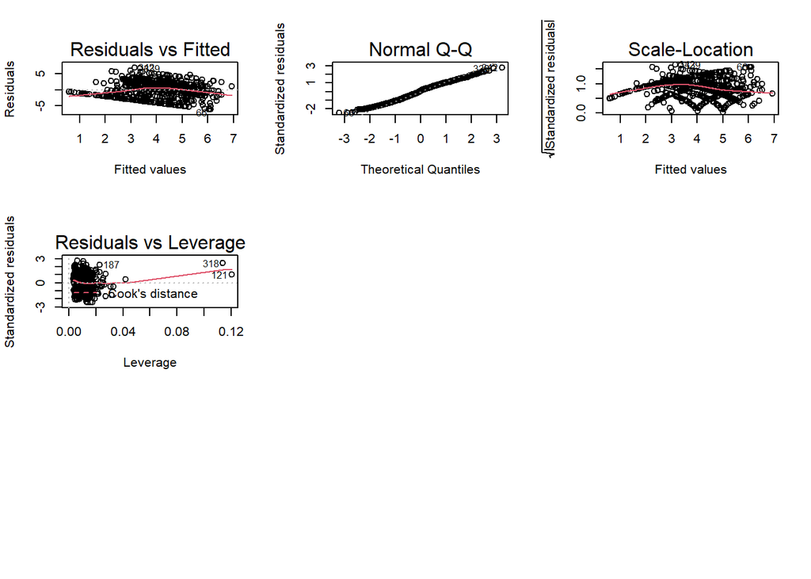

  ```r
    par(mfrow = c(3, 3))
    plot(acer_main_mod)

     par(mfrow = c(3, 3))
  ```

[figure not shown]

````
2\. You may have noticed that the variable cover is defined as
positive integers between 1 and 10. and is therefore better treated
as a discrete rather than continuous variable.
Re-examine your solutions to the question above but from the
perspective of a General Linear Model (GLM) with a Poisson error term
(rather than a Gaussian one as in OLS).
The Poisson distribution generates integers 0 to positive infinity so this may provide a good first approximation.
Your new model calls will look as follows:

```r
acer_poi = glm(cover ~ tci + elev + ... , data = my_data,
           family='poisson')
````

```r
acer_poi = glm(cover ~ tci + elev + streamdist + disturb + beers, data = acer, family = "poisson")

abies_poi = glm(cover ~ tci + elev + streamdist + disturb + beers, data = abies, family = "poisson")
```

For assessing the degree of variation explained you can use a pseudo-R-squared statistic (note this is just one of many possible)

```r
pseudo_r2 = function(glm_mod) {
                1 -  glm_mod$deviance / glm_mod$null.deviance
            }
```

```r
psuedo_r2 = function(glm_mod) {
                1 - glm_mod$deviance / glm_mod$null.deviance
}

psuedo_r2(acer_poi)
```

```
## [1] 0.1342074
```

```r
psuedo_r2(abies_poi)
```

```
## [1] 0.8951796
```

Compare your qualatitive assessment of which variables were most important in each model.

[output not shown]

Does it appear that changing the error distribution changed the results much? In what ways?

[output not shown]

3. Provide a plain English summary (i.e., no statistics) of what you have found and what conclusions we can take away from your analysis?

```
  #From the analysis, we can conclude that elevation, stream distribution,
  and disturbance are heavily impacting the tree cover of the "abies" trees,
  and that elevation, tci, and beers are impacting the "acer" tree cover.
  These differences in siginficant variables suggest which habitats the
  specialist species can grow compared to a generalist species, where tree
  cover is a measure of growth/population size.
```